# Analysis of Variance

Tanujit Chakraborty

Statistical Inference (SI 350) Course

## One-way Analysis of Variance (One-way ANOVA)

The Analysis of Variance, or ANOVA in short, refers broadly to a collection of experimental situations and statistical procedures for the analysis of quantitative responses from experimental units. The simplest of them is referred to as a **single-factor**, or **one-way ANOVA**. It involves the analysis either of data sampled from more than two populations or of data from experiments in which more than two treatments have been used. The characteristic that differentiates the treatments or populations from one another is called the **factor** under study, and the different treatments or populations are referred to as the **levels** of the factor.

Some examples:

- An experiment to study the effect of different fertilizers on the yield of a crop.
- An experiment to study drug effectiveness on a disease.
- An experiment to study effect of different insecticides on pest control.

Consider the ‘InsectSprays’ dataset in R.

```r
data("InsectSprays")
dat <- InsectSprays
head(InsectSprays)
```

```
##   count spray
## 1    10     A
## 2     7     A
## 3    20     A
## 4    14     A
## 5    14     A
## 6    12     A
```

```r
str(InsectSprays)
```

```
## 'data.frame':    72 obs. of  2 variables:
##  $ count: num  10 7 20 14 14 12 10 23 17 20 ...
##  $ spray: Factor w/ 6 levels "A","B","C","D",..: 1 1 1 1 1 1 1 1 1 1 ...
```

```r
#Show the levels of treatment

levels(dat$spray)
```

```
## [1] "A" "B" "C" "D" "E" "F"
```

Let us visualize the data.

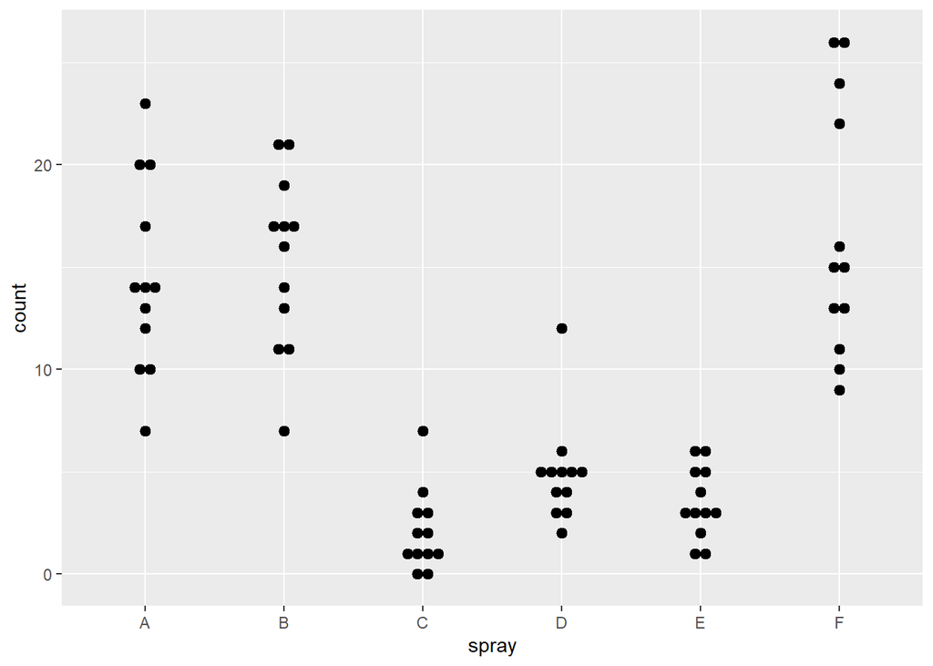

Single factor ANOVA focuses on a comparison of more than two populations or treatment means. Let

- $I$ = number of treatment levels
- $J_i$ = number of observations in level $i$, $i = 1,\ldots,I$
- $\mu_i$ = mean of treatment level $i$, $i = 1,\ldots,I$
- $N = \sum_{i=1}^I J_i$ = total number of observations

The relevant hypotheses are
$$H_0: \mu_1 = \ldots = \mu_I\; vs.\; H_1: not\; H_0$$
The alternative hypothesis is tantamount to saying that at least one pair of means are different.

### The ANOVA Model

Let $X_{ij}$ denote the random variable representing the $j$th measurement taken from the $i$th treatment, and $x_{ij}$ be the observed value of the same.

The one-way ANOVA model is given by
$$X_{ij} = \mu_i + \epsilon_{ij},$$
where $\epsilon_{ij}$ are the error terms. We assume that $\epsilon_{ij} \stackrel{iid}{\sim}N(0,\sigma^2)$.

This gives,
$$E(X_{ij}) = \mu_i,\; Var(X_{ij}) = \sigma^2.$$

An alternative description of the one-way ANOVA is given by
$$X_{ij} = \mu + \alpha_i + \epsilon_{ij},$$
where $\mu = \frac{1}{I}{\sum_{i=1}^I\mu_i},$ and $\alpha_i = \mu_i - \mu,\, i = 1,\ldots,I$. Note that $\sum_{i=1}^{I}\alpha_i = 0.$ The null hypothesis above thus becomes
$$H_0: \alpha_1 = \ldots = \alpha_I = 0.$$

The individual sample means are denoted as $\bar{X}_{10},\ldots,\bar{X}_{I0}$, such that $\bar{X}_{i0} = \frac{1}{J_i}\sum_{j=1}^{J_i} X_{ij}$, and the grand mean is denoted as $\bar{X}_{00} = \frac{1}{N}\sum_{i=1}^I\sum_{j=1}^{J_i} X_{ij}.$

Think about the total variation in the data. The observed values of the variable of interest are $X_{ij}$, and the grand mean is $\bar{X}_{00}$. Thus, the total variation in the data is given by the *Total Sum of Squares* (SST), defined as
$$SST = \sum_{i=1}^I\sum_{j=1}^{J_i} (X_{ij} - \bar{X}_{00})^2.$$
The total SS can be partitioned in to two sums, as $SST = SSTr + SSE,$ where
$$SSTr = \sum_{i=1}^I\sum_{j=1}^{J_i} (\bar{X}_{i0} - \bar{X}_{00})^2, \; SSE = \sum_{i=1}^I\sum_{j=1}^{J_i} (X_{ij} - \bar{X}_{i0})^2.$$
For a proof of the same, please refer to the Appendix at the end of this document. The above identity says that the total variation can be partitioned into two parts. *SSTr* measures the variation (between levels) that can be explained by possible differences in the $\mu_i$s (How would SSTr behave if all the $\mu_i$s were identical to each other?) On the other hand, *SSE* measures variation (within levels) that would be present irrespective of whether $H_0$ is true or false.

Let us look at our ‘InsectSprays’ data example again.

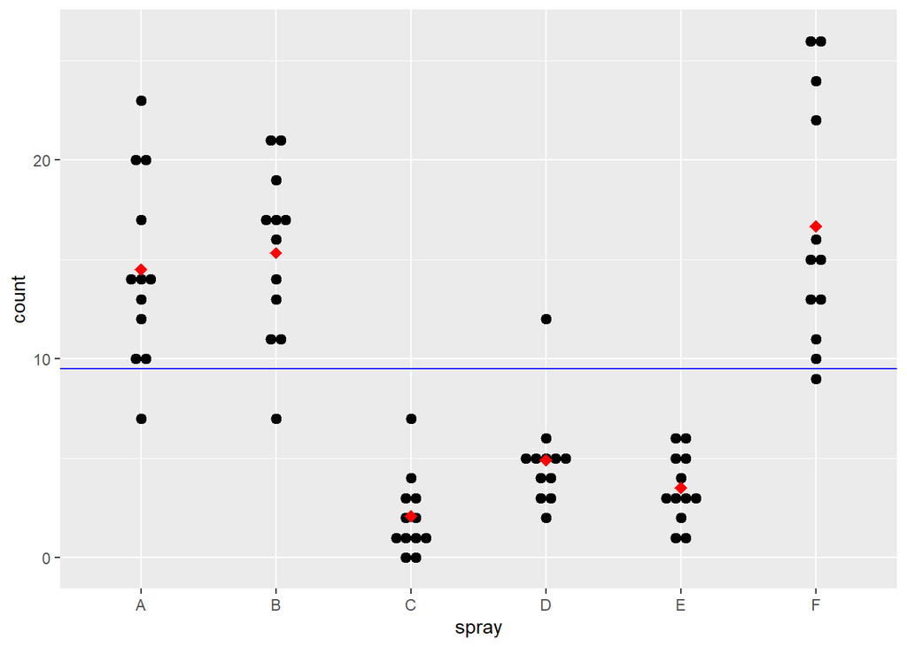

The red dots are the within level sample means $\bar{X}_{i0}$ and the blue line corresponds to the overall grand mean $\bar{X}_{00}$. *SSTr* looks at the variation between levels, taking the squared differences of the red dot with the blue line, whereas *SSE* looks at the variation within levels, taking squared differences of the black dots with the red dots for each level.

If the null hypothesis is true, then, *SSTr* would have a significantly smaller contribution to the total variation *SST*. This intuitive idea forms the basis of ANOVA. You must be wondering why a comparison of means is coined as analysis of **variance**. To answer this, let us look into the theoretical properties of the quantities *SSTr* and *SSE*.

In this context, we define the **Mean Squared Treatment**(MSTr) and **Mean Squared Error**(MSE) as
$$MSTr = SSTr/(I-1),\; MSE = SSE/(N-I).$$
Note that, if we denote the sample variance for the $i$th treatment level as $S_i^2$, then, $MSE = \dfrac{(J_1-1)S_1^2 + \cdots + (J_I-1)S_I^2}{(J_1-1)+ \cdots + (J_I-1)} = \dfrac{(J_1-1)S_1^2 + \cdots + (J_I-1)S_I^2}{N-I}.$

We can prove (for proofs, refer to the appendix) that,
$$E(SSTr) = (I-1)\sigma^2 + \sum_{i=1}^{I}J_i\alpha_i^2,\; E(SSE) = (N - I)\sigma^2,$$
so that,
$$E(MSTr) = \sigma^2 + \dfrac{1}{I-1}\sum_{i=1}^{I}J_i\alpha_i^2,\; E(MSE) = \sigma^2.$$

If $H_0$ is true, then, $\alpha_i = 0,\; i=1,\ldots,I$, and thus, $E(MSTr) = \sigma^2 = E(MSE)$. On the other hand, if $H_0$ is not true, then, $E(MSTr) > E(MSE) = \sigma^2.$ Denoting $E(MSTr)$ as $\sigma_*^2$, we can reformulate the testing of hypothesis problem as
$$H_0:\sigma_*^2 = \sigma^2 \; vs.\; H_1:\sigma_*^2 > \sigma^2.$$
Thus, the hypothesis of testing of means has boiled down to testing of variances. Also, it is a right-tailed test.

The test statistic in this case is given by $F = \dfrac{MSTr}{MSE}.$ We reject $H_0$ at level of significance $\alpha$ if $\mathrm{obsvd.}(F) > F_{\alpha,I-1,N-I}.$

We illustrate the ANOVA testing procedure in *R*. We shall use the **aov** function in *R*, and the **summary()** command to get the **ANOVA Table**.

```r
anova.fit <- aov(count ~ spray, data = dat)
summary(anova.fit)
```

```
##             Df Sum Sq Mean Sq F value Pr(>F)
## spray        5   2669   533.8    34.7 <2e-16 ***
## Residuals   66   1015    15.4
## ---
## Signif. codes:  0 '***' 0.001 '**' 0.01 '*' 0.05 '.' 0.1 ' ' 1
```

### Multiple comparisons in ANOVA

Our analysis is terminated if we fail to reject the null hypothesis, owing to the fact that there are no differences in the treatment means across levels. However, if the null hypothesis is rejected, the next step would be to determine which pairs of treatment means differ. We can either perform pairwise testing one at a time, or a multiple comparisons procedure. In the former case, our hypotheses look like
$$H_0: \mu_r - \mu_s = 0 \; vs.\; H_1:\mu_r - \mu_s \neq 0.$$
We can adopt a two-sample t-test procedure for carrying out the above test. It will be a pooled t-test (why?), with the estimator of $\sigma^2$ given by *MSE*. The $100(1-\alpha)\%$ confidence interval for $\mu_i - \mu_j$ is given by
$$\bar{X}_{r0} - \bar{X}_{s0} \mp t_{\alpha,N-I}\sqrt{MSE(1/J_r + 1/J_s)}.$$

The **summary.lm** command gives us the level-specific estimates and significance results.

```r
summary.lm(anova.fit)
```

```
##
## Call:
## aov(formula = count ~ spray, data = dat)
##
## Residuals:
##    Min     1Q Median     3Q    Max
## -8.333 -1.958 -0.500  1.667  9.333
##
## Coefficients:
##             Estimate Std. Error t value Pr(>|t|)
## (Intercept)  14.5000     1.1322  12.807  < 2e-16 ***
## sprayB        0.8333     1.6011   0.520    0.604
## sprayC      -12.4167     1.6011  -7.755 7.27e-11 ***
## sprayD       -9.5833     1.6011  -5.985 9.82e-08 ***
## sprayE      -11.0000     1.6011  -6.870 2.75e-09 ***
## sprayF        2.1667     1.6011   1.353    0.181
## ---
## Signif. codes:  0 '***' 0.001 '**' 0.01 '*' 0.05 '.' 0.1 ' ' 1
##
## Residual standard error: 3.922 on 66 degrees of freedom
## Multiple R-squared:  0.7244, Adjusted R-squared:  0.7036
## F-statistic:  34.7 on 5 and 66 DF,  p-value: < 2.2e-16
```

## Interpretation of the R Output

- The ANOVA Table (obtained by the summary() command) is the standard ANOVA table.
- Interesting thing is the one obtained using the summary.lm command.
- Look at the `Coefficients’ table. The first row (Intercept) corresponds to the baseline control group (Spray A in this case). The value of 14.5 is the mean of the baseline control group and the corresponding t-test tests whether the effect of that spray is zero or not. In this example, the null hypothesis of the mean effect for the control group = 0 is rejected owing to the extremely low p-value. The next rows corresponf to the difference of the other levels of treatment with the control group (like Spray B - Spray A, Spray C - Spray A, etc.). The estimates reported are that of the respective differences of the other treatment levels with the control group.
- Notice that the standard errors are the same across all the differences, and this is due to the fact that the expression for the standard error involves the MSE with equal number of observations per group.
- The corresponding t-tests test for the difference of the treatment levels with the control group.
- Now look at the Residual standard error in the bottom of the table. It can be obtained from the ANOVA table above by taking the square root of the MSE.
- Also, the Multiple-R-squared $(R^2)$ value is obtained as (SSTr/(SSTr + SSE)).

### Tukey’s HSD Method

However, the above method provides Confidence intervals at the desired level for individual pairs of means, but not a simultaneous one which controls the overall confidence level for all the pairs. To answer this, we resort to the multiple comparisons procedure. The intervals are based on **Studentized range statistic**, Tukey’s *Honest Significant Difference* method.

```r
TukeyHSD(anova.fit)
```

```
##   Tukey multiple comparisons of means
##     95% family-wise confidence level
##
## Fit: aov(formula = count ~ spray, data = dat)
##
## $spray
##            diff        lwr       upr     p adj
## B-A   0.8333333  -3.866075  5.532742 0.9951810
## C-A -12.4166667 -17.116075 -7.717258 0.0000000
## D-A  -9.5833333 -14.282742 -4.883925 0.0000014
## E-A -11.0000000 -15.699409 -6.300591 0.0000000
## F-A   2.1666667  -2.532742  6.866075 0.7542147
## C-B -13.2500000 -17.949409 -8.550591 0.0000000
## D-B -10.4166667 -15.116075 -5.717258 0.0000002
## E-B -11.8333333 -16.532742 -7.133925 0.0000000
## F-B   1.3333333  -3.366075  6.032742 0.9603075
## D-C   2.8333333  -1.866075  7.532742 0.4920707
## E-C   1.4166667  -3.282742  6.116075 0.9488669
## F-C  14.5833333   9.883925 19.282742 0.0000000
## E-D  -1.4166667  -6.116075  3.282742 0.9488669
## F-D  11.7500000   7.050591 16.449409 0.0000000
## F-E  13.1666667   8.467258 17.866075 0.0000000
```

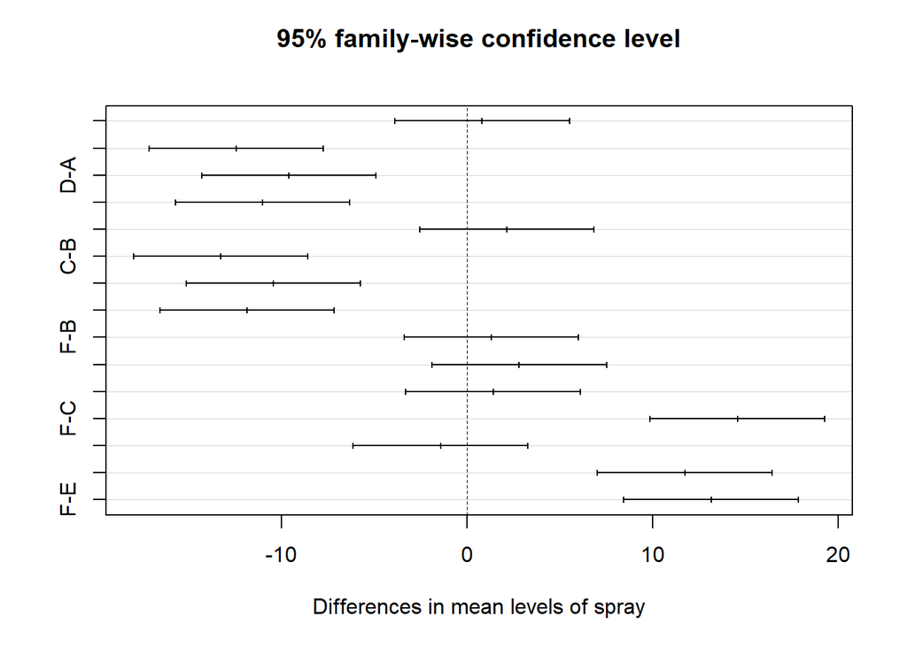

```r
plot(TukeyHSD(anova.fit))
```

### Problems.

**1**. Sorbonne University Abu Dhabi decides to install a new smart-chip option for cars entering or exiting the campus in order to facilitate smooth and automatic passage of cars through the main entrance, without being frisked manually by the security guards. Registered vehicles belonging to people affiliated with the Institute are provided with an electronic tag to be displayed on the windshield, which automatically activates the smart-chip on the gate while approaching the same. The response time in milliseconds for activating the smart-chip was determined for three different positions of placing the electronic tag: upper right corner (UR), lower right corner (LR), and upper left corner (UL) of the windshield. The results are shown in the table below.

| Tag position | Activation time |
| --- | --- |
| UR | 9, 12, 10, 8, 15 |
| LR | 20, 21, 23, 17, 30 |
| UL | 6, 5, 8, 16, 7 |

Perform an ANOVA test using the above data to determine whether the three positions have any effect on the response time for activating the smart-chip on the gate.

**Solution.**

```r
# Input data
UR <- c(9,12,10,8,15)
LR <- c(20, 21, 23, 17, 30)
UL <- c(6,5,8,16,7)

# Store data as a vector
activation.time <- c(UR, LR, UL)

# Treatment levels
tag.position <- factor(rep(c("UR","LR","UL"), each = 5))

# Perform one-way ANOVA
aov.out <- aov(activation.time ~ tag.position)

# ANOVA Table
summary(aov.out)
```

```
##              Df Sum Sq Mean Sq F value   Pr(>F)
## tag.position  2  543.6   271.8   16.08 0.000402 ***
## Residuals    12  202.8    16.9
## ---
## Signif. codes:  0 '***' 0.001 '**' 0.01 '*' 0.05 '.' 0.1 ' ' 1
```

```r
# Pairwise comparison
summary.lm(aov.out)
```

```
##
## Call:
## aov(formula = activation.time ~ tag.position)
##
## Residuals:
##    Min     1Q Median     3Q    Max
##   -5.2   -2.3   -1.2    1.0    7.8
##
## Coefficients:
##                Estimate Std. Error t value Pr(>|t|)
## (Intercept)      22.200      1.838  12.075 4.51e-08 ***
## tag.positionUL  -13.800      2.600  -5.308 0.000186 ***
## tag.positionUR  -11.400      2.600  -4.385 0.000889 ***
## ---
## Signif. codes:  0 '***' 0.001 '**' 0.01 '*' 0.05 '.' 0.1 ' ' 1
##
## Residual standard error: 4.111 on 12 degrees of freedom
## Multiple R-squared:  0.7283, Adjusted R-squared:  0.683
## F-statistic: 16.08 on 2 and 12 DF,  p-value: 0.0004023
```

```r
# Tukey's HSD
TukeyHSD(aov.out)
```

```
##   Tukey multiple comparisons of means
##     95% family-wise confidence level
##
## Fit: aov(formula = activation.time ~ tag.position)
##
## $tag.position
##        diff        lwr       upr     p adj
## UL-LR -13.8 -20.736445 -6.863555 0.0005042
## UR-LR -11.4 -18.336445 -4.463555 0.0023656
## UR-UL   2.4  -4.536445  9.336445 0.6367043
```

We find that activation times for UR and UL do not differ, but both of them differs with the same for LR.

### Appendix

> Proof of SST = SSTr + SSE

We have,
$$SST = \sum_{i=1}^I\sum_{j=1}^{J_i} (X_{ij} - \bar{X}_{00})^2= \sum_{i=1}^I\sum_{j=1}^{J_i} (X_{ij} - \bar{X}_{i0} + \bar{X}_{i0} - \bar{X}_{00})^2$$
$$= \sum_{i=1}^I\sum_{j=1}^{J_i} (\bar{X}_{i0} - \bar{X}_{00})^2 + \sum_{i=1}^I\sum_{j=1}^{J_i} (X_{ij} - \bar{X}_{i0})^2 = SSTr + SSE.$$

> Expression for E(SSTr)

Note that
$$\bar{X}_{io} = \frac{1}{J_i}\sum_{j=1}^{J_i}X_{ij} = \frac{1}{J_i}\sum_{j=1}^{J_i}(\mu + \alpha_i + \epsilon_{ij}) = \mu + \alpha_i + \bar{\epsilon}_{i0},\;$$
and,
$$\bar{X}_{00} = \frac{1}{N}\sum_{i=1}^I \sum_{j=1}^{J_i}X_{ij} = \frac{1}{J_i}\sum_{j=1}^{J_i}(\mu + \alpha_i + \epsilon_{ij}) = \mu + \bar{\epsilon}_{00}$$
.

Thus,

$$SSTr = \sum_{i=1}^I\sum_{j=1}^{J_i} (\bar{X}_{i0} - \bar{X}_{00})^2
= \sum_{i=1}^I\sum_{j=1}^{J_i}(\alpha_i + \bar{\epsilon}_{i0} - \bar{\epsilon}_{00})^2 = \sum_{i=1}^I\sum_{j=1}^{J_i}\alpha_i^2 + \sum_{i=1}^I\sum_{j=1}^{J_i}(\bar{\epsilon}_{i0} - \bar{\epsilon}_{00})^2.$$
$$= \sum_{i=1}^{I}J_i\alpha_i^2 + \sum_{i=1}^I\sum_{j=1}^{J_i}(\bar{\epsilon}^2_{io} + \bar{\epsilon}^2_{00} - 2\bar{\epsilon}_{i0}\bar{\epsilon}_{00}) = \sum_{i=1}^{I}J_i\alpha_i^2 + \sum_{i=1}^I J_i\bar{\epsilon}^2_{i0} + N\bar{\epsilon}^2_{00} - 2\bar{\epsilon}_{00}\sum_{i=1}^I J_i\bar{\epsilon}_{i0}$$
$$= \sum_{i=1}^{I}J_i\alpha_i^2 + \sum_{i=1}^I \bar{\epsilon}^2_{io} + N\bar{\epsilon}^2_{00} - 2\bar{\epsilon}_{00}\sum_{i=1}^I \sum_{j=1}^{J_i}\epsilon_{ij} = \sum_{i=1}^{I}J_i\alpha_i^2 + \sum_{i=1}^I J_i\bar{\epsilon}^2_{i0} + N\bar{\epsilon}^2_{00} - 2N\bar{\epsilon}^2_{00} = \sum_{i=1}^{I}J_i\alpha_i^2 + \sum_{i=1}^I J_i\bar{\epsilon}^2_{i0} - N\bar{\epsilon}^2_{00}$$
Note that,
$$\bar{\epsilon}_{i0} \stackrel{indep}{\sim}N(0,\dfrac{\sigma^2}{J_i}),\; \bar{\epsilon}_{00} \sim N(0,\dfrac{\sigma^2}{N}).$$

Thus,
$$E(SSTr) = \sum_{i=1}^{I}J_i\alpha_i^2 + \sum_{i=1}^I J_i\dfrac{\sigma^2}{J_i} - N\dfrac{\sigma^2}{N} = \sum_{i=1}^{I}J_i\alpha_i^2 + (I-1)\sigma^2.$$